# Experimenting with U-Net on Pytorch

Jouko Kinnari May 17, 2019

## Introduction

This implementation of a semantic segmentation network was written as project work for course CS-E4890 course in Aalto University in spring 2019.

## References

[1] https://arxiv.org/abs/1505.04597 Olaf Ronneberger, Philipp Fischer, Thomas Brox: U-Net: Convolutional Networks for Biomedical Image Segmentation, 18 May 2015

## Differences compared to original implementation

- Modifications for separation border described in [1] are not implemented.
- Network is constructed so that an arbitrary amount of classes can be used.
- The network uses KITTI segmentation data but it can be adapted easily for using other datasources by modifying the Dataset class.
- A batch normalization layer is added after each convolutional layer in attempt to improve convergence.

## How to train and run the model

See information in [Github page](https://github.com/jkinnari/unet_pytorch/blob/master/README.md)

Run each cell in consecutive order. Each code cell contains an ample number of comments for easy follow-up.

## Improvement opportunities/missing features

```python
import os
import numpy as np
import matplotlib.pyplot as plt
import matplotlib
%matplotlib inline
#%matplotlib notebook
import glob

import torch
import torchvision
import torchvision.transforms as transforms
import torch.nn as nn
import torch.nn.functional as F
import torch.optim as optim
import torchvision.transforms.functional as TF
import pandas as pd
from torch.utils.data import Dataset, DataLoader
from skimage import io, transform, color
import skimage
from PIL import Image
import time

from IPython import display

from collections import namedtuple

# For debugging CUDA-related errors in more details, let's set the following environment variable.
os.environ['CUDA_LAUNCH_BLOCKING'] = "1"
```

## Define some global parameters for the network and define paths to data

```python
# Let's specify the training images and the testing images and corresponding annotation files.
# Adjust the paths to data depending on where you have stored the data.

# Training images and segmentations.
training_image_directory = 'datasets/kitti_semantics/training/image_2'
training_segmentation_directory = 'datasets/kitti_semantics/training/semantic'

# Path for storing models to
model_storage_path = './'
```

```python
# The input and output layers of the network will have this many pixels per dimension.
# Let's select the same number of pixels as in the original publication [1]
terminal_layers_dimension_px = 572

# Images are normalized with given std and mean parameters as defined in pytorch.transforms.Normalize
normalization_avg = 0.5
normalization_std = 0.5

# Number of output channels of classification (i.e. number of classes)
num_output_channels = 29
```

```python
# Select the device for training. Use GPU if available.
device = torch.device('cuda' if torch.cuda.is_available() else 'cpu')
```

## Dataset class definition

```python
# Let's use a custom dataset class for loading images and segmentations.
class KittiSemanticsDataset(Dataset):
    """Kitti Semantics dataset."""

    def __init__(self,images_dir,segmentations_dir,idsToClassesLookup,classNames,transform=None):

        glob_pattern_for_images = os.path.join(images_dir, "*.png")

        paths_to_images = glob.glob(glob_pattern_for_images)

        self.samples = {}
        self.transform = transform

        self.idsToClassesLookup = idsToClassesLookup
        self.classNames = classNames

        # Check that segmentation exists for each image and construct a dict of image-segmentation pairs.
        for path_to_image in paths_to_images:
            [head, tail] = os.path.split(path_to_image)
            # Tail should now hold e.g. "000000540280.png". Let's check if the corresponding .png file
            # exists in segmentations_dir .

            fileparts = tail.split(".")
            filename_body = fileparts[0]

            path_to_segmentation_image = os.path.join(segmentations_dir,filename_body + '.png')

            if (os.path.isfile(path_to_segmentation_image)):
                self.samples[filename_body] = (path_to_image, path_to_segmentation_image)
            else:
                raise FileNotFoundError("No matching segmentation image found in directory " + segmentations_dir + " for image " + tail + ". Make sure you have given the correct image and segmentation paths.")

    def __len__(self):
        return len(self.samples)

    def __getitem__(self, idx):
        # Select path to an individual image based on index. For accessing based on index, create a list from dict.
        (path_to_image, path_to_segmentation_image) = list(self.samples.values())[idx]
        file_body = list(self.samples)[idx]

        image = io.imread(path_to_image)

        # Segmentation indexing, when read from original png image, needs to be incremented with 1 for an unknown reason.
        segmentation_with_original_ids = io.imread(path_to_segmentation_image)

        segmentation = np.zeros(segmentation_with_original_ids.shape)

        # Based on lookup table, transform IDs in segmentation file to the classes we want to identify.
        for key, value in self.idsToClassesLookup.items():
            segmentation[segmentation_with_original_ids==key] = value

        # skimage.io stores image with different axes order than expected by some implementations
        # in Pytorch. For this reason, convert from height-width-channels order to channels-height-width order.

        try:
            image = image.transpose((2,0,1))
        except ValueError as ve:
            print("Value error when handling {}: {}".format(file_body,ve))
            print("Image shape: {}".format(image.shape))

        #segmentation = segmentation.transpose((2,0,1))

        # Store image, segmentation and body of filename in sample.
        # Body of filename is used only for debugging purposes in case something peculiar happens with
        # a specific image.
        sample = {'image': image, 'segmentation': segmentation, 'body': file_body}

        if self.transform:
            sample = self.transform(sample)

        return sample

    def visualize_item(self, idx):
        """Helper function for visualizing a given item in dataset."""
        item = self.__getitem__(idx)

        # Convert image from tensor to Numpy array and shuffle axes to get to height-width-channels order.
        image_for_imshow = item['image'].numpy().transpose((1,2,0))

        # Perform "counter-normalization" of image.
        image_for_imshow = image_for_imshow * normalization_std + normalization_avg

        # For plotting, convert segmentation from tensor to Numpy array.
        segmentation_for_imshow = item['segmentation'].numpy().astype(int)

        showImageAndSegmentations(image_for_imshow,segmentation_for_imshow, classLabels=self.classNames)
```

## Helper functions

```python
# Define a helper function for visualizing an image and its segmentation.
def showImageAndSegmentations(image=None,segmentationgt=None,segmentationOutput=None,classLabels=None):
        if (image is not None):
            # Plot image if given.
            fig_img = plt.figure(figsize=(7,7))
            imgplot = plt.imshow(image)
            plt.title('Image')

        #cmap=matplotlib.cm.get_cmap(name='tab20')
        cmap = plt.cm.rainbow
        norm = matplotlib.colors.BoundaryNorm(np.arange(0,len(classLabels),1), cmap.N)

        if (segmentationgt is not None):
            # Plot segmentation ground truth if given.
            fig_seggt = plt.figure(figsize=(7,7))
            seggtplot = plt.imshow(segmentationgt)
            plt.title('Segmentation ground truth')
            seggtplot.set_cmap(cmap)
            seggtplot.set_norm(norm)
            plt.colorbar()

        if (segmentationOutput is not None):
            # Plot segmentation output if given.
            fig_segout = plt.figure(figsize=(7,7))
            segoutplot = plt.imshow(segmentationOutput)
            plt.title('Segmentation output')
            segoutplot.set_cmap(cmap)
            segoutplot.set_norm(norm)
            plt.colorbar()


        if (classLabels is not None):
            for key, value in classLabels.items():
                print("{}: {}".format(key,value))
```

```python
# Define a helper function for cropping a batch from the middle so that its shape matches that of example batch.
def cropToMatchSample(x,example,multichannel=True):
    # Get shape of x.
    xShape = x.shape

    # Get target shape.
    targetedShape = example.shape

    # The width and height are stored in shape vectors' dimensions with indexes 2 and 3.
    target_width = targetedShape[-2]
    target_height = targetedShape[-1]

    source_width = xShape[-2]
    source_height = xShape[-1]

    # Let's calculate the crop start and end indexes for width and height in the array that we want to concatenate.
    crop_start_idx_width = np.floor((source_width-target_width)/2).astype(int)
    crop_end_idx_width = crop_start_idx_width + target_width

    crop_start_idx_height = np.floor((source_height-target_height)/2).astype(int)
    crop_end_idx_height = crop_start_idx_height + target_height

    #print("Crop indexes, width: {},{}".format(crop_start_idx_width,crop_end_idx_width))
    #print("Crop indexes, height: {},{}".format(crop_start_idx_height,crop_end_idx_height))

    # Based on the calculated cropping start and end indexes, crop the array, taking into account
    # both the case when there is just one signal and the case where there are multiple signals.

    if (multichannel):
        retval = x[:,:,crop_start_idx_width:crop_end_idx_width,crop_start_idx_height:crop_end_idx_height]
    else:
        retval = x[:,crop_start_idx_width:crop_end_idx_width,crop_start_idx_height:crop_end_idx_height]

    #print("Array shape after cropping: {}".format(retval.shape))

    return retval
```

```python
# Define a helper function that flattens a batch of size BATCH * CLASSES * H * W to BATCH * H * W
def flatten_segmentation_output(segmentation_output):
    values, indices = torch.max(segmentation_output, dim=1)
    flattened_segmentation_output = indices

    return flattened_segmentation_output
```

```python
# Define a function for easy calculation of intersection-over-union per class.
epsilon = 1e-9

def calculate_ious(outputs: torch.Tensor, labels: torch.Tensor):

    outputs = outputs.squeeze(0).cpu().numpy()
    labels = labels.squeeze(0).cpu().numpy()

    # Find out which unique classes there are in the outputs and true labels:
    unique_classes_in_labels = np.unique(labels)
    unique_classes_in_outputs = np.unique(outputs)
    unique_classes = np.sort(np.unique(np.concatenate((unique_classes_in_labels,unique_classes_in_outputs))))

    ious = dict()
    weights = dict()

    # Go through each class and calculate IoU for that class
    for i, c in enumerate(unique_classes):

        outputs_binary_mask = np.zeros(outputs.shape).astype(np.bool)
        labels_binary_mask = np.zeros(labels.shape).astype(np.bool)

        outputs_binary_mask[outputs==c] = 1
        labels_binary_mask[labels==c] = 1

        intersection = outputs_binary_mask & labels_binary_mask
        union = outputs_binary_mask | labels_binary_mask

        # Calculate intersection-over-union
        ious[i] = (np.sum(intersection)+epsilon)/(np.sum(union)+epsilon)

    return ious
```

## Definition of data transformations

```python
# Define a number of custom transforms. We cannot use the Pytorch readily implemented transforms as such, because
# we typically want to do the same transforms on both the image and the segmentation.

class RectangularCropAndScaleTransform(object):
    """Crop a maximal rectangle from middle of picture and rescale to given pixel side width."""

    def __init__(self,rectangle_side_width_px):
        self.rectangle_side_width_px = rectangle_side_width_px

    def __call__(self, sample):
        image, segmentation, body = sample['image'], sample['segmentation'], sample['body']

        c, h, w = image.shape

        # Based on image dimensions (portrait or landscape), calculate indexes used in cropping the image
        # to rectangular shape.
        if (w<h):
            # Image is portrait-shaped
            crop_horiz_start_idx = 0
            crop_horiz_end_idx = w

            crop_vert_start_idx = np.floor((h - w)/2).astype(int)
            crop_vert_end_idx = crop_vert_start_idx + w
        else:
            # Image is landscape or rectangular
            crop_horiz_start_idx = np.floor((w - h)/2).astype(int)
            crop_horiz_end_idx = crop_horiz_start_idx + h

            crop_vert_start_idx = 0
            crop_vert_end_idx = h

        #print('h: {}, w: {}, crop_vert_start_idx: {}, crop_vert_end_idx: {}, crop_horiz_start_idx: {}, crop_horiz_end_idx: {}'.format(h, w, crop_vert_start_idx, crop_vert_end_idx, crop_horiz_start_idx, crop_horiz_end_idx))

        # Crop by selecting indexes
        image = image[:,crop_vert_start_idx:crop_vert_end_idx,crop_horiz_start_idx:crop_horiz_end_idx]
        segmentation = segmentation[crop_vert_start_idx:crop_vert_end_idx,crop_horiz_start_idx:crop_horiz_end_idx]
        #segmentation = segmentation[:,crop_vert_start_idx:crop_vert_end_idx,crop_horiz_start_idx:crop_horiz_end_idx]

        # Scale to desired dimensions
        image = transform.resize(image.transpose((1,2,0)),(self.rectangle_side_width_px,self.rectangle_side_width_px)).transpose((2,0,1))

        # For the segmentation, we want to use 0th order interpolation to keep the original class indexes intact.
        # We also want to keep data type as integer.
        segmentation = transform.resize(segmentation,(self.rectangle_side_width_px,self.rectangle_side_width_px),order=0,preserve_range=True).astype(int)

        return {'image': image, 'segmentation': segmentation, 'body': body}


class ToTensorTransform(object):
    """Convert sample to tensors"""
    def __call__(self, sample):
        image, segmentation, body = sample['image'], sample['segmentation'], sample['body']
        #image = torch.from_numpy(image)
        #segmentation = torch.from_numpy(segmentation)
        image = torch.Tensor(image)
        segmentation = torch.Tensor(segmentation)

        return {'image': image, 'segmentation': segmentation, 'body': body}

class NormalizeImageTransform(object):
    """Normalization of a sample"""
    def __init__(self, mean, std):
        self.mean = mean
        self.std = std

    def __call__(self, sample):
        image, segmentation, body = sample['image'], sample['segmentation'], sample['body']

        image = torchvision.transforms.functional.normalize(image,(self.mean,self.mean,self.mean),(self.std,self.std,self.std))

        return {'image': image, 'segmentation': segmentation, 'body': body}
```

```python
# Define a composition of the transforms we created above.
composed_transforms = transforms.Compose([RectangularCropAndScaleTransform(terminal_layers_dimension_px),
                                         ToTensorTransform(),
                                          NormalizeImageTransform(normalization_avg,normalization_std),
                                         ])
```

## Selection of classes that are relevant to us

This implementation allows grouping of classes. This is beneficial in case the segmentation labeling data contains too many classes to be relevant for us. For example, we may not be interested in making a distinction between a pole or a polegroup, or e.g. the type of a vehicle.

The final intended use case for this network is not disclosed in this course exercise.

```python
# Class names:
classNames = dict()
classNames[0] = 'Don\'t care'
classNames[1] = 'ground' # orig id = 6
classNames[2] = 'road' # orig id = 7
classNames[3] = 'sidewalk' # orig id = 8
classNames[4] = 'parking' # orig id = 9
classNames[5] = 'railtrack' # orig id = 10
classNames[6] = 'building' # orig id = 11
classNames[7] = 'wall' # orig id = 12
classNames[8] = 'fence' # orig id = 13
classNames[9] = 'guardrail' # orig id = 14
classNames[10] = 'bridge' # orig id = 15
classNames[11] = 'tunnel' # orig id = 16
classNames[12] = 'pole' # orig id = 17
classNames[13] = 'polegroup' # orig id = 18
classNames[14] = 'trafficlight' # orig id = 19
classNames[15] = 'trafficsign' # orig id = 20
classNames[16] = 'vegetation' # orig id = 21
classNames[17] = 'terrain' # orig id = 22
classNames[18] = 'sky' # orig id = 23
classNames[19] = 'person' # orig id = 24
classNames[20] = 'rider' # orig id = 25
classNames[21] = 'car' # orig id = 26
classNames[22] = 'truck' # orig id = 27
classNames[23] = 'bus' # orig id = 28
classNames[24] = 'caravan' # orig id = 29
classNames[25] = 'trailer' # orig id = 30
classNames[26] = 'train' # orig id = 31
classNames[27] = 'motorcycle' # orig id = 32
classNames[28] = 'bicycle' # orig id = 33
classNames[29] = 'license plate'

# Mapping of original ids to class names:
classIdLookup = dict()
classIdLookup[0]  = 0 #'unlabeled': id = 0
classIdLookup[1]  = 0 #'egovehicle': id = 1
classIdLookup[2]  = 0 #'rectificationborder': id = 2
classIdLookup[3]  = 0 #'outofroi': id = 3
classIdLookup[4]  = 0 #'static': id = 4
classIdLookup[5]  = 0 #'dynamic': id = 5
classIdLookup[6]  = 1 #'ground': id = 6
classIdLookup[7]  = 2 #'road': id = 7
classIdLookup[8]  = 3 #'sidewalk': id = 8
classIdLookup[9]  = 4 #'parking': id = 9
classIdLookup[10] = 5 #'railtrack': id = 10
classIdLookup[11] = 6 #'building': id = 11
classIdLookup[12] = 7 #'wall': id = 12
classIdLookup[13] = 8 #'fence': id = 13
classIdLookup[14] = 9 #'guardrail': id = 14
classIdLookup[15] = 10 #'bridge': id = 15
classIdLookup[16] = 11 #'tunnel': id = 16
classIdLookup[17] = 12 #'pole': id = 17
classIdLookup[18] = 13 #'polegroup': id = 18
classIdLookup[19] = 14 #'trafficlight': id = 19
classIdLookup[20] = 15 #'trafficsign': id = 20
classIdLookup[21] = 16 #'vegetation': id = 21
classIdLookup[22] = 17 #'terrain': id = 22
classIdLookup[23] = 18 #'sky': id = 23
classIdLookup[24] = 19 #'person': id = 24
classIdLookup[25] = 20 #'rider': id = 25
classIdLookup[26] = 21 #'car': id = 26
classIdLookup[27] = 22 #'truck': id = 27
classIdLookup[28] = 23 #'bus': id = 28
classIdLookup[29] = 24 #'caravan': id = 29
classIdLookup[30] = 25 #'trailer': id = 30
classIdLookup[31] = 26 #'train': id = 31
classIdLookup[32] = 27 #'motorcycle': id = 32
classIdLookup[33] = 28 #'bicycle': id = 33
classIdLookup[-1] = 29 #'licenseplate': id = -1
```

## Setting up loaders for training and testing data

```python
# Define dataset.
kittidataset = KittiSemanticsDataset(training_image_directory,training_segmentation_directory,classIdLookup,classNames,composed_transforms)

# Split dataset to training and validation data.
datasetSize = len(kittidataset)
indices=list(range(datasetSize))

# Shuffle list of indices with a given random seed.
# We are specifying an arbitrary random seed here explicitly so that we can reproduce generation of the training
# and testing datasets exactly.
randomSeed = 123
np.random.seed(randomSeed)
np.random.shuffle(indices)

# Select specified fraction of data for testing and the rest for teaching.
testingFraction = 0.2
splitIndex = int(np.floor(testingFraction * datasetSize))

# Select training and testing indices.
trainingIndices = indices[splitIndex:]
testingIndices = indices[:splitIndex]

# Define training and testing data samplers
trainingSampler = torch.utils.data.sampler.SubsetRandomSampler(trainingIndices)
testingSampler = torch.utils.data.sampler.SubsetRandomSampler(testingIndices)

# Define trainloader and testloader
trainloader = torch.utils.data.DataLoader(kittidataset, batch_size=1, sampler=trainingSampler)
testloader = torch.utils.data.DataLoader(kittidataset, batch_size=1, sampler=testingSampler)

print("Finished setting up trainloader and testloader")
```

```
Finished setting up trainloader and testloader
```

## Tool for visualizing random items from dataset

```
0: Don't care
1: ground
2: road
3: sidewalk
4: parking
5: railtrack
6: building
7: wall
8: fence
9: guardrail
10: bridge
11: tunnel
12: pole
13: polegroup
14: trafficlight
15: trafficsign
16: vegetation
17: terrain
18: sky
19: person
20: rider
21: car
22: truck
23: bus
24: caravan
25: trailer
26: train
27: motorcycle
28: bicycle
29: license plate
```

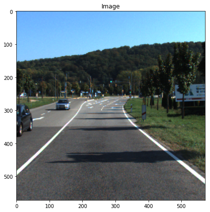

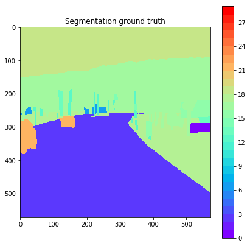

```python
# Visualize a random item from dataset.
kittidataset.visualize_item(np.random.randint(0,len(kittidataset)))
```

## Definition of U-Net class

```python
# Define a number of block classes for easier construction of the U-net.

# In the contracting path, according to [1], each block consists of following layers:
# 3x3 convolution, unpadded
# ReLU
# 3x3 convolution, unpadded
# ReLU
# 2x2 max pooling, stride = 2
# Let's write a class for this type of block.
# Note that the output of the latter 3x3 convolution + ReLu is used in the expansive path.

class ContractingBlock(nn.Module):
    def __init__(self,in_channels,out_channels, doMaxPool=True):
        super(ContractingBlock, self).__init__()
        self.in_channels = in_channels
        self.out_channels = out_channels
        self.doMaxPool = doMaxPool

        self.conv2d_1 = nn.Conv2d(in_channels=self.in_channels, out_channels=self.out_channels,kernel_size=3,padding=0)
        self.bnorm_1 = nn.BatchNorm2d(self.out_channels)
        self.conv2d_2 = nn.Conv2d(in_channels=self.out_channels, out_channels=self.out_channels,kernel_size=3,padding=0)
        self.bnorm_2 = nn.BatchNorm2d(self.out_channels)

        if (self.doMaxPool):
            self.maxpool2d = nn.MaxPool2d(2,stride=2)

    def forward(self,x):
        x = self.conv2d_1.forward(x)
        x = F.relu(x)
        x = self.bnorm_1.forward(x)
        x = self.conv2d_2.forward(x)
        x = F.relu(x)
        x = self.bnorm_2.forward(x)

        # If we want to do max pooling, return not only the value x but also the value of x before max pooling.
        if (self.doMaxPool):

            x_before_maxpool = x
            x = self.maxpool2d.forward(x)
            # Now we return not just x but also x before maxpool, because in the expansive path we will utilize that.
            return (x,x_before_maxpool)
        else:
            return x

# In the expansive path, according to [1], each block consists of the following layers:
# Upsampling
# 2x2 convolution ("up-convolution") that halves number of feature channels
# Concatenation with correspondingly cropped feature map from contracting path
# 3x3 convolution
# ReLU
# 3x3 convolution
# ReLU
# Let's write a class for this type of block.

class ExpansiveBlock(nn.Module):
    def __init__(self,in_channels,out_channels):
        super(ExpansiveBlock, self).__init__()
        self.in_channels = in_channels
        self.out_channels = out_channels

        self.convTranspose2d=nn.ConvTranspose2d(self.in_channels,self.out_channels,kernel_size=2,stride=2)

        # Layers after concatenation are stored in a block for convenience.
        self.blockAfterConcatenation = nn.Sequential(
            nn.Conv2d(self.in_channels, self.out_channels,kernel_size=3,padding=0),
            nn.ReLU(),
            nn.BatchNorm2d(self.out_channels),
            nn.Conv2d(self.out_channels, self.out_channels,kernel_size=3,padding=0),
            nn.ReLU(),
            nn.BatchNorm2d(self.out_channels)
        )

    def forward(self,x,arrayToConcatenate):
        x = self.convTranspose2d.forward(x) # Up-convolution

        # The unpadded convolutions lose edge values at each step. For that reason,
        # we can't just concatenate the array from the contracting path as is and we
        # crop the image a bit as explained in original paper [1].
        croppedArrayToConcatenate = cropToMatchSample(arrayToConcatenate,x)

        #print("Array shape after cropping: {}".format(croppedArrayToConcatenate.shape))

        x = torch.cat((x,croppedArrayToConcatenate), dim=1) # Concatenate in the signals dimension
        x = self.blockAfterConcatenation.forward(x)
        return x

# Define the U-net network.
class UNet(nn.Module):
    def __init__(self,numSignalsInInput,numLabels,verbose=False):
        super(UNet, self).__init__()

        self.numSignalsInInput = numSignalsInInput
        self.numLabels = numLabels

        # Initialize contracting path.
        self.cblock1 = ContractingBlock(numSignalsInInput,64)
        self.cblock2 = ContractingBlock(64,128)
        self.cblock3 = ContractingBlock(128,256)
        self.cblock4 = ContractingBlock(256,512)

        # In the final contracting block. On this block we don't want to do max pooling.
        self.cblock5 = ContractingBlock(512,1024,doMaxPool=False)

        # Initialize expansive path.
        self.eblock1 = ExpansiveBlock(1024,512)
        self.eblock2 = ExpansiveBlock(512,256)
        self.eblock3 = ExpansiveBlock(256,128)
        self.eblock4 = ExpansiveBlock(128,64)

        # Initialize final layer.
        self.finalLayer = nn.Conv2d(64,self.numLabels,1)


    def forward(self, x, verbose=False):

        # Compute contracting path and keep record of outputs of each contracting block for concatenation later.

        if (verbose):
            print("Shape of x at input: {}".format(x.shape))

        (x, x_c1) = self.cblock1.forward(x)
        (x, x_c2) = self.cblock2.forward(x)
        (x, x_c3) = self.cblock3.forward(x)
        (x, x_c4) = self.cblock4.forward(x)
        x = self.cblock5.forward(x)

        # Compute expansive path and give corresponding outputs from contracting path for cropping and concatenation.

        if (verbose):
            print("Shape of x after contracting path: {}".format(x.shape))
            print("Shape of x_c4: {}".format(x_c4.shape))

        x = self.eblock1.forward(x,x_c4)

        if (verbose):
            print("Shape of x after eblock1: {}".format(x.shape))

        x = self.eblock2.forward(x,x_c3)

        if (verbose):
            print("Shape of x after eblock2: {}".format(x.shape))

        x = self.eblock3.forward(x,x_c2)

        if (verbose):
            print("Shape of x after eblock3: {}".format(x.shape))

        x = self.eblock4.forward(x,x_c1)

        if (verbose):
            print("Shape of x after eblock4: {}".format(x.shape))

        # Compute output of final layer
        x = self.finalLayer.forward(x)

        return x
```

```python
# Let's construct the U-net network
net = UNet(3,num_output_channels,verbose=False)
net.to(device)
```

```
UNet(
  (cblock1): ContractingBlock(
    (conv2d_1): Conv2d(3, 64, kernel_size=(3, 3), stride=(1, 1))
    (bnorm_1): BatchNorm2d(64, eps=1e-05, momentum=0.1, affine=True, track_running_stats=True)
    (conv2d_2): Conv2d(64, 64, kernel_size=(3, 3), stride=(1, 1))
    (bnorm_2): BatchNorm2d(64, eps=1e-05, momentum=0.1, affine=True, track_running_stats=True)
    (maxpool2d): MaxPool2d(kernel_size=2, stride=2, padding=0, dilation=1, ceil_mode=False)
  )
  (cblock2): ContractingBlock(
    (conv2d_1): Conv2d(64, 128, kernel_size=(3, 3), stride=(1, 1))
    (bnorm_1): BatchNorm2d(128, eps=1e-05, momentum=0.1, affine=True, track_running_stats=True)
    (conv2d_2): Conv2d(128, 128, kernel_size=(3, 3), stride=(1, 1))
    (bnorm_2): BatchNorm2d(128, eps=1e-05, momentum=0.1, affine=True, track_running_stats=True)
    (maxpool2d): MaxPool2d(kernel_size=2, stride=2, padding=0, dilation=1, ceil_mode=False)
  )
  (cblock3): ContractingBlock(
    (conv2d_1): Conv2d(128, 256, kernel_size=(3, 3), stride=(1, 1))
    (bnorm_1): BatchNorm2d(256, eps=1e-05, momentum=0.1, affine=True, track_running_stats=True)
    (conv2d_2): Conv2d(256, 256, kernel_size=(3, 3), stride=(1, 1))
    (bnorm_2): BatchNorm2d(256, eps=1e-05, momentum=0.1, affine=True, track_running_stats=True)
    (maxpool2d): MaxPool2d(kernel_size=2, stride=2, padding=0, dilation=1, ceil_mode=False)
  )
  (cblock4): ContractingBlock(
    (conv2d_1): Conv2d(256, 512, kernel_size=(3, 3), stride=(1, 1))
    (bnorm_1): BatchNorm2d(512, eps=1e-05, momentum=0.1, affine=True, track_running_stats=True)
    (conv2d_2): Conv2d(512, 512, kernel_size=(3, 3), stride=(1, 1))
    (bnorm_2): BatchNorm2d(512, eps=1e-05, momentum=0.1, affine=True, track_running_stats=True)
    (maxpool2d): MaxPool2d(kernel_size=2, stride=2, padding=0, dilation=1, ceil_mode=False)
  )
  (cblock5): ContractingBlock(
    (conv2d_1): Conv2d(512, 1024, kernel_size=(3, 3), stride=(1, 1))
    (bnorm_1): BatchNorm2d(1024, eps=1e-05, momentum=0.1, affine=True, track_running_stats=True)
    (conv2d_2): Conv2d(1024, 1024, kernel_size=(3, 3), stride=(1, 1))
    (bnorm_2): BatchNorm2d(1024, eps=1e-05, momentum=0.1, affine=True, track_running_stats=True)
  )
  (eblock1): ExpansiveBlock(
    (convTranspose2d): ConvTranspose2d(1024, 512, kernel_size=(2, 2), stride=(2, 2))
    (blockAfterConcatenation): Sequential(
      (0): Conv2d(1024, 512, kernel_size=(3, 3), stride=(1, 1))
      (1): ReLU()
```

[output cut: 26 more lines]

```
    )
  )
  (eblock4): ExpansiveBlock(
    (convTranspose2d): ConvTranspose2d(128, 64, kernel_size=(2, 2), stride=(2, 2))
    (blockAfterConcatenation): Sequential(
      (0): Conv2d(128, 64, kernel_size=(3, 3), stride=(1, 1))
      (1): ReLU()
      (2): BatchNorm2d(64, eps=1e-05, momentum=0.1, affine=True, track_running_stats=True)
      (3): Conv2d(64, 64, kernel_size=(3, 3), stride=(1, 1))
      (4): ReLU()
      (5): BatchNorm2d(64, eps=1e-05, momentum=0.1, affine=True, track_running_stats=True)
    )
  )
  (finalLayer): Conv2d(64, 29, kernel_size=(1, 1), stride=(1, 1))
)
```

## Optimization parameters

```python
# Define loss and optimizer
criterion = torch.nn.CrossEntropyLoss()
optimizer = optim.SGD(net.parameters(), lr=0.01, momentum=0.99)

# Parameters for training
n_epochs = 100
```

## Training loop

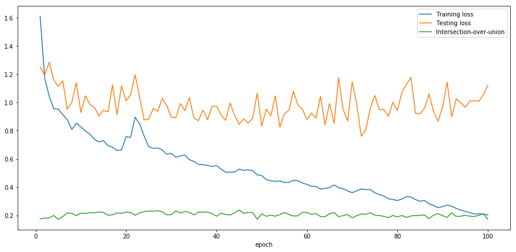

[output not shown]

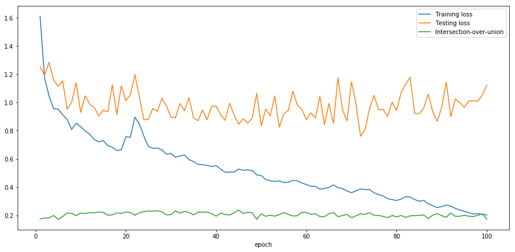

```python
# Training loop

training_losses = []
testing_losses = []
testing_ious = []
epochs = []

fig, ax = plt.subplots(1,1,figsize=(15,7))


print("Starting training")

start_time = time.time()

for epoch in range(n_epochs):

    running_training_loss = 0.0
    running_testing_loss = 0.0

    # Go through training dataset and backpropagate errors to parameters
    net.train()
    for i, sample in enumerate(trainloader, 0):
        image = sample['image']
        segmentation = sample['segmentation']
        body = sample['body']

        #print("Processing image {}".format(body))

        # Transfer to GPU
        image, segmentation = image.to(device), segmentation.to(device, dtype=torch.int64)

        # zero the parameter gradients
        optimizer.zero_grad()

        # forward pass
        outputs = net(image)

        # Due to unpadded convolutions, the u-net structure loses pixels from the sides of the picture.
        # Let's crop the ground truth segmentation picture so that it matches the output of the network.
        cropped_segmentation = cropToMatchSample(segmentation,outputs,multichannel=False)

        # calculate loss
        training_loss = criterion(outputs, cropped_segmentation)

        # backward pass
        training_loss.backward()

        # take a step with optimizer
        optimizer.step()

        # print statistics
        running_training_loss += training_loss.item()

    # Go through testing dataset (forward pass only) and calculate loss and IoU performance indicators
    net.eval()

    iou_statistics = dict()

    with torch.no_grad():
        for i, sample in enumerate(testloader, 0):
            image = sample['image']
            segmentation = sample['segmentation']
            body = sample['body']

            # Transfer to GPU
            image, segmentation = image.to(device), segmentation.to(device, dtype=torch.int64)

            # forward pass
            outputs = net(image)

            cropped_segmentation = cropToMatchSample(segmentation,outputs,multichannel=False)

            # calculate loss
            testing_loss = criterion(outputs, cropped_segmentation)
            running_testing_loss += testing_loss.item()

            # calculate Intersection-over-Unions (IoUs)
            flattened_outputs = flatten_segmentation_output(outputs)
            ious = calculate_ious(flattened_outputs, cropped_segmentation)

            # store calculated IoUs in a statistics dict
            for key, value in ious.items():
                if key in iou_statistics.keys():
                    iou_statistics[key] = iou_statistics[key] + value
                else:
                    iou_statistics[key] = value


    # Scale losses by number of samples to get comparable numbers for training and testing losses
    training_loss = running_training_loss / len(trainloader)
    testing_loss = running_testing_loss / len(testloader)

    # Also scale IoUs similarly to get mean of intersection-over-unio per class
    for key, value in iou_statistics.items():
        iou_statistics[key] = value/len(testloader)

    # Calculate average IoU over all classes
    avg_iou = sum(iou_statistics.values())/len(iou_statistics)

    training_losses.append(training_loss)
    testing_losses.append(testing_loss)
    testing_ious.append(avg_iou)
    epochs.append(epoch+1)

    # Plot losses, update after each epoch
    ax.clear()
    ax.plot(epochs, training_losses, label='Training loss')
    ax.plot(epochs, testing_losses, label='Testing loss')
    ax.plot(epochs, testing_ious, label='Intersection-over-union')
    ax.set(xlabel='epoch')
    ax.legend()

    display.clear_output(wait=True)
    display.display(fig)

    time_now = time.time()

    estimated_duration_of_teaching_s = (time_now-start_time)/(epoch+1)*n_epochs
    estimated_time_left_s = estimated_duration_of_teaching_s - (time_now-start_time)

    print("Epoch {}/{} completed, training loss={:.3f}, testing loss={:.3f}, estimated teaching time remaining {:.2f} h/{:.2f} h".format(epoch+1,n_epochs,training_loss,testing_loss,estimated_time_left_s/60/60, estimated_duration_of_teaching_s/60/60))
    print("Intersection-over-union statistics:")
    for key, value in iou_statistics.items():
        print("class {}: average IoU = {:.3f}".format(key,value))

    print("average IoU over all classes: {:.3f}".format(avg_iou))

print('Finished training')

net.eval()

# After the given number of epochs, save model to file. Construct model filename from current date and time.
model_filename = "unet_model_" + time.strftime("%Y_%m_%d_%H_%M_%S", time.gmtime()) + ".pth"

path_to_model_file = os.path.join(model_storage_path,model_filename)

print("Saving to {}".format(path_to_model_file))
torch.save(net.state_dict(), path_to_model_file)

print('Saved')
```

## Loading a pretrained model from disk

Use this only when you want to load a pretrained model and not use the model you taught in the previous cell.

```python
# This cell can be used for loading a pretrained model from disk.

path_to_load_model_from = 'unet_model_2019_05_16_14_06_50.pth'

net = UNet(3,num_output_channels,verbose=False)
net.load_state_dict(torch.load(path_to_load_model_from))
net.to(device)
net.eval()
```

```
UNet(
  (cblock1): ContractingBlock(
    (conv2d_1): Conv2d(3, 64, kernel_size=(3, 3), stride=(1, 1))
    (bnorm_1): BatchNorm2d(64, eps=1e-05, momentum=0.1, affine=True, track_running_stats=True)
    (conv2d_2): Conv2d(64, 64, kernel_size=(3, 3), stride=(1, 1))
    (bnorm_2): BatchNorm2d(64, eps=1e-05, momentum=0.1, affine=True, track_running_stats=True)
    (maxpool2d): MaxPool2d(kernel_size=2, stride=2, padding=0, dilation=1, ceil_mode=False)
  )
  (cblock2): ContractingBlock(
    (conv2d_1): Conv2d(64, 128, kernel_size=(3, 3), stride=(1, 1))
    (bnorm_1): BatchNorm2d(128, eps=1e-05, momentum=0.1, affine=True, track_running_stats=True)
    (conv2d_2): Conv2d(128, 128, kernel_size=(3, 3), stride=(1, 1))
    (bnorm_2): BatchNorm2d(128, eps=1e-05, momentum=0.1, affine=True, track_running_stats=True)
    (maxpool2d): MaxPool2d(kernel_size=2, stride=2, padding=0, dilation=1, ceil_mode=False)
  )
  (cblock3): ContractingBlock(
    (conv2d_1): Conv2d(128, 256, kernel_size=(3, 3), stride=(1, 1))
    (bnorm_1): BatchNorm2d(256, eps=1e-05, momentum=0.1, affine=True, track_running_stats=True)
    (conv2d_2): Conv2d(256, 256, kernel_size=(3, 3), stride=(1, 1))
    (bnorm_2): BatchNorm2d(256, eps=1e-05, momentum=0.1, affine=True, track_running_stats=True)
    (maxpool2d): MaxPool2d(kernel_size=2, stride=2, padding=0, dilation=1, ceil_mode=False)
  )
  (cblock4): ContractingBlock(
    (conv2d_1): Conv2d(256, 512, kernel_size=(3, 3), stride=(1, 1))
    (bnorm_1): BatchNorm2d(512, eps=1e-05, momentum=0.1, affine=True, track_running_stats=True)
    (conv2d_2): Conv2d(512, 512, kernel_size=(3, 3), stride=(1, 1))
    (bnorm_2): BatchNorm2d(512, eps=1e-05, momentum=0.1, affine=True, track_running_stats=True)
    (maxpool2d): MaxPool2d(kernel_size=2, stride=2, padding=0, dilation=1, ceil_mode=False)
  )
  (cblock5): ContractingBlock(
    (conv2d_1): Conv2d(512, 1024, kernel_size=(3, 3), stride=(1, 1))
    (bnorm_1): BatchNorm2d(1024, eps=1e-05, momentum=0.1, affine=True, track_running_stats=True)
    (conv2d_2): Conv2d(1024, 1024, kernel_size=(3, 3), stride=(1, 1))
    (bnorm_2): BatchNorm2d(1024, eps=1e-05, momentum=0.1, affine=True, track_running_stats=True)
  )
  (eblock1): ExpansiveBlock(
    (convTranspose2d): ConvTranspose2d(1024, 512, kernel_size=(2, 2), stride=(2, 2))
    (blockAfterConcatenation): Sequential(
      (0): Conv2d(1024, 512, kernel_size=(3, 3), stride=(1, 1))
      (1): ReLU()
```

[output cut: 26 more lines]

```
    )
  )
  (eblock4): ExpansiveBlock(
    (convTranspose2d): ConvTranspose2d(128, 64, kernel_size=(2, 2), stride=(2, 2))
    (blockAfterConcatenation): Sequential(
      (0): Conv2d(128, 64, kernel_size=(3, 3), stride=(1, 1))
      (1): ReLU()
      (2): BatchNorm2d(64, eps=1e-05, momentum=0.1, affine=True, track_running_stats=True)
      (3): Conv2d(64, 64, kernel_size=(3, 3), stride=(1, 1))
      (4): ReLU()
      (5): BatchNorm2d(64, eps=1e-05, momentum=0.1, affine=True, track_running_stats=True)
    )
  )
  (finalLayer): Conv2d(64, 29, kernel_size=(1, 1), stride=(1, 1))
)
```

## Testing model in practice with a sample from testing dataset

```
0: Don't care
1: ground
2: road
3: sidewalk
4: parking
5: railtrack
6: building
7: wall
8: fence
9: guardrail
10: bridge
11: tunnel
12: pole
13: polegroup
14: trafficlight
15: trafficsign
16: vegetation
17: terrain
18: sky
19: person
20: rider
21: car
22: truck
23: bus
24: caravan
25: trailer
26: train
27: motorcycle
28: bicycle
29: license plate
```

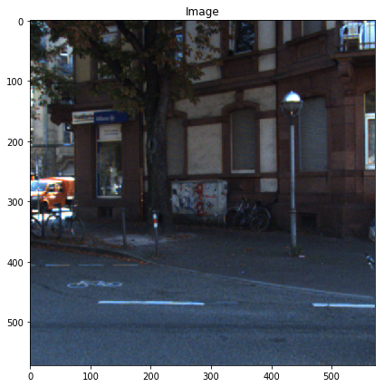

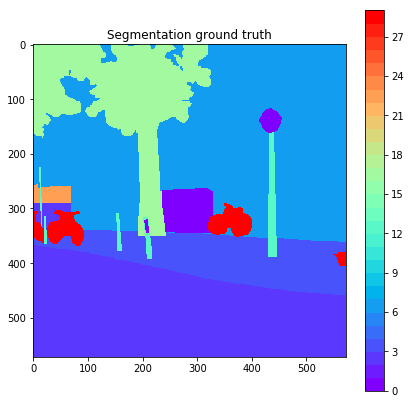

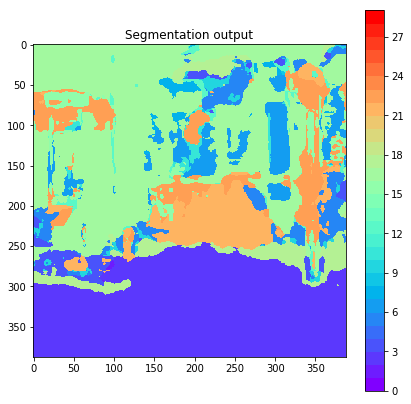

```python
# Visualize the segmentation of a random example with the trained model, from testing set
itemNumber = np.random.randint(0,len(testingIndices))

sample = kittidataset.__getitem__(testingIndices[itemNumber])

with torch.no_grad():
    # Our unet implementation assumes that the data fed to it has dimensions batch * signals * width * height.
    # When only looking at a single image, without using a dataloader, we need to add batch dimension
    # to image tensor manually by using unsqueeze.
    image = sample['image'].unsqueeze(0).to(device)

    outputs = net(image).cpu()

    flattened_outputs = flatten_segmentation_output(outputs).squeeze(0)

    output_segmentation_for_imshow = flattened_outputs.numpy().astype(int)
    image_for_imshow = sample['image'].numpy().transpose((1,2,0)) * normalization_std + normalization_avg
    segmentationgt_for_imshow = sample['segmentation'].numpy()

    showImageAndSegmentations(image_for_imshow,segmentationgt_for_imshow,flattened_outputs,classLabels=kittidataset.classNames)
```